# Proctor Data Analysis Assessment

Chunyi Yu

2023-04-16

# Background

From Won et al.(2017) Am J Trop Med Hyg: https://www.ncbi.nlm.nih.gov/pmc/articles/PMC5462587/

Schistosomiasis, caused by infection with Schistosoma spp., affects more than 200 million people worldwide. Prevalence and intensity of infection with Schistosoma mansoni peak between 10 and 15 years of age and gradually decline with age. In children, chronic schistosomiasis is associated with anemia and malnutrition and can compromise growth and cognitive development. Because of the influence school-aged children have on transmission of schistosomiasis, mass treatment of this age group with praziquantel has been the cornerstone of schistosomiasis control activities. Until recently, disease burden and morbidity among preschool-aged children have remained understudied. However, recent research has shown that first infection is often acquired at a very young age, and there is growing evidence that the burden of disease among PSAC may warrant global attention.

A field study was conducted from 2012 to 2014 in Mbita subcounty, which borders Lake Victoria in western Kenya. Before the start of the study, malaria interventions had been in place for several years, but no mass drug administration (MDA) for schistosomiasis had been conducted.

Thirty villages that met the selection criteria were randomized into two study arms to compare different MDA strategies for schistosomiasis and STH programs. Fifteen villages were randomized to a community-wide treatment arm and the remaining 15 villages were randomized to a school-based treatment arm. In each of the 30 study villages, the study aimed to enroll 100 preschool aged children (1~5 years) and their mothers or guardians.

In both study arms, parasitologic and serologic indicators were monitored at baseline (year 1 in 2012) and annually following treatment. All annual monitoring was done using repeated, cross-sectional surveys in the selected villages and children were treated with praziquantal and albendazole approximately 2 months after each annual measurement.

# 1 Download and process the data (data cleaning)

1. Review the data and codebooks. Familiarize yourself with them. Then, read in the data. (These data are very clean so unlike most projects there is not an extensive amount of data processing required. In reality, data processing is often the most time consuming part of a project!) Depending on how you approach the work below, if you want to join the two datasets the 1:many key variable is village id (vid).
2. Create a derived variable that is an indicator of whether the child was seropositive to either the SEA antigen or the Sm25 antigen. We will be using a combined measure of serpositivity as the outcome!

```r
  kids  <- read.table ("C:/Users/fjyuc/Desktop/DATAGAME/R/Assessment_proctor_UCSF_Grace/test/mbita_schisto.csv", header=TRUE, sep=",")
  villages  <- read.table ("C:/Users/fjyuc/Desktop/DATAGAME/R/Assessment_proctor_UCSF_Grace/test/mbita_spatial.csv", header=TRUE, sep=",")

  library(dplyr)
  complete<-left_join(kids,villages, by="vid")
  complete$serop_indi<-ifelse(complete$sea_pos ==1|complete$sm25_pos==1,1,0)

  #transform to factor
  complete <- transform(complete,
                          vid=factor(vid),
                          year=factor(year,levels=c(2012, 2013, 2014), labels=c("2012","2013","2014")),
                          arm=factor(arm,levels=c("CWT","SBT"),labels=c("CWT","SBT")),
                          sex=factor(sex,levels=c("male","female"), labels=c("M","F")),
                          sea_pos=factor(sea_pos,levels=c(0,1),labels=c("No","Yes")),   #  seropositive to the SEA antigen;
                          sm25_pos=factor(sm25_pos,levels=c(0,1),labels=c("No","Yes")), # seropositive to the Sm25 antigen;
                          kk_pos=factor(kk_pos,levels=c(0,1),labels=c("No","Yes")), # Kato-Katz positive for S. mansoni;
                          serop_indi=factor(serop_indi,levels=c(0,1),labels=c("No","Yes"))) # seropositive to SEA or Sm25.

    label(complete$vid)       <- "Village ID"
    label(complete$pid)       <- "Child ID"
    label(complete$year)      <- "Study year"
    label(complete$arm)       <- "Study arm"
    label(complete$agey)      <- "Age"
    label(complete$sex)       <- "Sex"
    label(complete$sea)       <- "Sea response"
    label(complete$sea_pos)   <- "Sea Positive"
    label(complete$sm25)      <- "Sm25 response"
    label(complete$sm25_pos)  <- "Sm25 Positive"
    label(complete$sm_epg)    <- "Eggs per gram"
    label(complete$kk_pos)    <- "KK Positive"
    label(complete$elev)      <- "Village elevation"
    label(complete$tmin)      <- "Average minimum temperature"
    label(complete$prec)      <- "Average precipitation"
    label(complete$dist_victoria)   <- "Distance to Lake Victoria"
    label(complete$serop_indi)      <- "A seropositivity indicator"

    units(complete$agey) <- "years"
    units(complete$elev) <- "meters"
    units(complete$tmin) <- "F"
    units(complete$prec) <- "mm"
    units(complete$dist_victoria) <- "meters"

    attach(complete)
```

This is a data containing information from a study on Schistosoma mansoni infection in children from 30 villages in Kenya over three years of 2012~2014. The dataset contains 3663 observations and 17 variables. Each observation represents a child who participated in the study. The variables include the study year, village ID, study arm, individual child ID, age, sex, measures of infection (SEA response, Sm25 response, and Kato-Katz eggs per gram of stool), seropositivity to SEA and Sm25 antigens, and Kato-Katz results. It also includes information on village elevation, average minimum temperature, average precipitation, distance to Lake Victoria. Finally, there is an indicator variable for whether the child was seropositive to either the SEA or Sm25 antigens, which is the primory outcome for this study.

#2 Describe the data (numeric summaries with data visualization)

Provide some simple descriptive summaries that help describe the data.  
For example, how many children were measured at baseline (2012) and in subsequent survey visits based on blood- and stool-based measures of infection? How complete were the measurements? For quantitative variables, is there anything you see about their distribution that might be important to consider in any downstream analysis? There is no one way to do this and we are not looking for a specific result. We are interested to learn how you would describe the data to have a sense for what it contains.

```r
# 1. how many children were measured at baseline (2012) and in subsequent survey visits based on blood- and stool-based measures of infection?

    library(dplyr)
    library(plyr)
    ddply(complete, c("sea","sm25","sm_epg")~ year,nrow)
```

```
##   c("sea", "sm25", "sm_epg") year  V1
## 1                        sea 2012 374
## 2                       <NA> 2013 395
## 3                       <NA> 2014 452
## 4                     sm_epg 2012 373
## 5                       <NA> 2013 396
## 6                       <NA> 2014 452
## 7                       sm25 2012 373
## 8                       <NA> 2013 396
## 9                       <NA> 2014 452
```

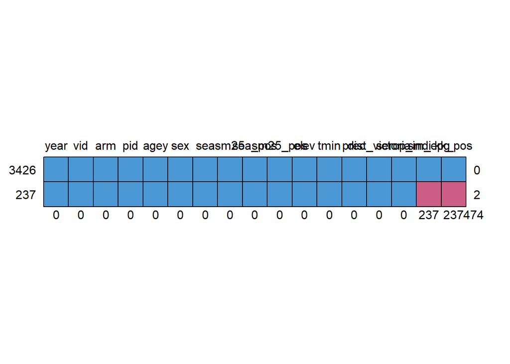

```
##      year vid arm pid agey sex sea sm25 sea_pos sm25_pos elev tmin prec
## 3426    1   1   1   1    1   1   1    1       1        1    1    1    1
## 237     1   1   1   1    1   1   1    1       1        1    1    1    1
##         0   0   0   0    0   0   0    0       0        0    0    0    0
##      dist_victoria serop_indi sm_epg kk_pos
## 3426             1          1      1      1   0
## 237              1          1      0      0   2
##                  0          0    237    237 474
```

```r
    #The first table shows the number of children measured at baseline and in the following two years for three different measures of infection. For the blood-based measure of infection with SEA, there were 374 children measured at baseline, 395 in the second year, and 452 in the third year. Similarly, for the blood-based measure of infection with sm_25, there were 373 children measured at baseline, 396 in the second year, and 452 in the third year. Lastly, for the stool-based measure of infection with egg per gram, there were 373 children measured at baseline, 396 in the second year, and 452 in the third year.



# 2.How complete were the measurements?
  library(mice)
  md.pattern(complete)
```